# 中东「土豪」叙事的事实与误读

GCC 财富的真实图景与三重误读

作者

Gen

发布于

2026年6月2日

# 引言

提起中东，「土豪」正在成为一个跨语言的刻板印象。中文媒体对其的经典描述是：「头顶一块布，天下我最富」。Netflix 上演到第三季的炫富真人秀 *Dubai Bling* 更是将这一形象推向了极致。

在对中东财富的期待中，不少中国企业在出海热潮中都将中东作为了考察的第一站。然而，风口的退潮也来得很快。一方面，中东地缘冲突此起彼伏；另一方面，沙特 The Line 等明星级基建项目接连传出延期和降级的新闻。有人开始怀疑，所谓「中东土豪」，是不是又一个被叙事放大的泡沫？

本研究的回答是，中东土豪不是泡沫，但「中东土豪」这一叙事至少误读了三件事，分别是把整个中东等同于 GCC、把国家财富等同于全民财富、把存量优势等同于长期无风险。GCC 的财富真实、巨大、且高度制度化，但它依赖油气租金、公民身份排他和地缘安全环境三根支柱。下文围绕这一判断展开。

# 1 厘清「中东」：地缘「中东」和财富「GCC」

关于中东，很多人会想到两种截然不同的画面。一边是迪拜、卡塔尔的奢华摩天大楼、豪车游艇；另一边是伊朗、叙利亚等国的战火纷飞。这两种画面虽然都被贴上了「中东」的标签，但所指的地理对象却几乎不重合。事实上，即便在不同的国际机构口径下，「中东」指代的国家清单可以从 6 国扩张到 30 多国不等。

因此，讨论中东土豪，第一步是厘清「中东」这个概念。

## 1.1 地缘「中东」：一个外部命名的起源

「中东」并非一个阿拉伯本土词汇，其从命名之日起就是一个由外部视角定义的战略概念。传统上，阿拉伯人以 *Mashriq*（المشرق，意为「阿拉伯东方」）和 *Maghreb*（المغرب，意为「阿拉伯西方」）作地理划分。

到了 1902 年，美国海军军官、《海权论》作者 Mahan 在英国《国家评论》（*National Review*）上发表文章，让「中东」（Middle East）这一概念在国际战略讨论中流行起来 (Mahan 1902)。Mahan 所指的区域专指波斯湾水道及其周边，理由是这一带是英帝国保卫殖民地交通线的战略要冲。

此后一个世纪，「中东」的边界随地缘政治风向反复扩张。二战中，英国「中东司令部」把开罗与北非纳入麾下；冷战期间，美国主导的中东集体安全体系（如 1955 年《巴格达条约》/ CENTO）把巴基斯坦也纳入这一战略框架；2004 年小布什政府的「大中东」（Greater Middle East）甚至把阿富汗与中亚部分国家也圈了进去 (Adelson 1995; Davison 1960)。

时至今日，至少存在四种并行的「中东」概念：

- **地理上**，中东覆盖西亚、阿拉伯半岛和黎凡特，有时延伸至北非和伊朗。
- **文化上**，中东被视为伊斯兰文明、阿拉伯世界或奥斯曼帝国的后继空间，因此可能纳入北非、中亚乃至南亚部分国家。
- **外交上**，「中东」概念更为分裂，即便几大国际机构的划定区域也有很大差异，其中 UN 完全不设「Middle East」统计大区，用纯地理的「西亚」+「北非」替代。
- **经济上**，上述概念中的中东的财富差距极大。卡塔尔 2024 年人均 GDP 约 7.7 万美元，也门不足 700 美元，两者相差超过百倍。

表 1: 主要国际组织中的中东定义

| 国家 / 地区 | UN | World Bank | IMF | US State |
| --- | --- | --- | --- | --- |
| GCC 六国（核心） | 西亚 | 含 | 含 | 含 |
| 伊拉克、约旦、黎巴嫩、叙利亚、也门、巴勒斯坦 | 西亚 | 含 | 含 | 含 |
| 伊朗 | 南亚 | 含 | 含 | 含 |
| 以色列 | 西亚 | 含 | 不含（归 Europe） | 含 |
| 埃及 | 北非 | 含 | 含 | 含 |
| 北非（除埃及） | 北非 | 含 | 含 | 含 |
| 阿富汗 / 巴基斯坦 | 南亚 | 含 | 含 | 不含 |

注：**UN M49**（联合国「国家或地区代码标准」）不设「Middle East」统计大区，用纯地理的「西亚」+「北非」替代 (United Nations Statistics Division 2026)；**World Bank MENAAP**（= Middle East + North Africa + Afghanistan + Pakistan）在原 MENA 基础上加入阿富汗、巴基斯坦，共 23 国 (World Bank 2025)；**IMF MCD**（中东与中亚部）覆盖 32 国与地区，含中亚、高加索，分析时常用子集 MENAP (International Monetary Fund 2025c)；**US State NEA**（近东事务局）沿用 19 世纪英国外交体系的「近东」旧称，覆盖 19 国加巴勒斯坦 (U.S. Department of State 2026)。

事实上，当人们谈论「中东财富」「中东资本」时，无论中文还是英文语境，所指几乎从不超出六个国家：沙特、阿联酋、卡塔尔、科威特、巴林、阿曼 。这六国共享一组高度相似的财富机制：高人均收入、巨额油气出口、大型主权财富基金、低所得税、覆盖公民「从摇篮到坟墓」的福利体系。在地理、文化、外交口径下各自飘移的「中东」，到财富视角下却收敛到了唯一稳定的对象。后文的所有分析都聚焦于 GCC 六国。

## 1.2 财富「GCC」：内部异质、外部同质

与「中东」概念的模糊不同，GCC 是一个有明确章程、固定成员的政府间组织。其正式英文名 *Cooperation Council for the Arab States of the Gulf*，通常简称「海湾合作委员会」。GCC 宪章于 1981 年 5 月 25 日在阿布扎比签署，总部设在利雅得 (Cooperation Council for the Arab States of the Gulf 1981)。GCC 成立的直接动因是 1979 年伊朗伊斯兰革命与 1980 年两伊战争，六个海湾君主国面对共同的外部安全压力，需要一个协调防御与经济的制度框架。从成立至今，GCC 成员国名单保持不变。

2024 年，GCC GDP 合计约 2.33 万亿美元，全球排名第 9，约占世界经济总量的 2.2%。这一体量大致相当于法国的四分之三、印度的六成。

GCC 六国呈现出「内部高度异质、外部高度同质」的双重特征。一方面，六国的内部差异极为悬殊：沙特一家的国土面积是巴林的 2,700 倍，GDP 是巴林的 26 倍；卡塔尔人均 GDP 接近阿曼的 4 倍。但差异之外存在一组高度一致的共性：六国全部是君主制，全部是沿海国家，外籍居民比例普遍超过本国公民。

对我们讨论 GCC 财富更重要的是，这六国共享四类深层机制：

1. 阿拉伯半岛与波斯湾沿岸的油气资源禀赋；
2. 高外籍劳工比例支撑的劳动力结构；
3. 低税、公民福利与主权财富基金相结合的「租金国家」财政模式；
4. 君主制下国家、王室、公民、外籍居民四层之间的清晰财富分配边界。

表 2: GCC 六国 2024 年核心数据

| 国家 | 人口 (2024) | 名义 GDP (2024, USD bn) | 人均 GDP (USD) | 土地面积 (km²) | 人口密度 (人/km²) |
| --- | --- | --- | --- | --- | --- |
| 沙特阿拉伯 | 3,530 万 | 1,239.8 | 35,121.7 | 2,149,690 | 16.4 |
| 阿联酋 | 1,099 万 | 552.3 | 50,273.5 | 71,020 | 154.7 |
| 卡塔尔 | 286 万 | 219.2 | 76,688.7 | 11,490 | 248.7 |
| 科威特 | 490 万 | 160.2 | 32,717.7 | 17,820 | 274.8 |
| 阿曼 | 528 万 | 107.1 | 20,285.2 | 309,500 | 17.1 |
| 巴林 | 159 万 | 47.1 | 29,653.6 | 800 | 1,985.8 |
| **GCC 合计** | **6,091 万** | **2,325.7** | 38,182.6 | **2,560,320** | **23.8** |

注：**人口与 GDP** 来自世界银行 2024 年口径 (World Bank 2026b)；**土地面积**用 WDI 的 land area 指标（AG.LND.TOTL.K2），剔除内陆水体、大陆架与专属经济区 (World Bank 2026a)。这一口径与各国官方常引用的「conventional total area」略有差异，最显著的是阿联酋（WDI 71,020 km² vs 常见 83,600 km²）；本节统一采用 WDI 口径。**人口总量**：世行加总 6,091 万与 GCC-Stat 年末 6,120 万 (GCC-Stat 2024) 相差约 0.5%（统计时点不同），正文统一引用「约 6,100 万」。**货币方面**，六国均与美元挂钩或紧盯：沙特里亚尔（SAR，1 USD ≈ 3.75 SAR）、阿联酋迪拉姆（AED，3.67 AED）、卡塔尔里亚尔（QAR，3.64 QAR）、巴林第纳尔（BHD，0.376 BHD）、阿曼里亚尔（OMR，0.385 OMR）、以及科威特第纳尔（KWD，1 KWD ≈ 3.26 USD，是当今全球面值最高的法定货币）。

### 1.2.1 六国对比：沙特一家独大，但比例并不一致

把六国份额并排比较，三个比例呈现明显的不一致格局。沙特在土地面积上几乎垄断（84%），在人口上仍是绝对主体（58%），但在 GDP 上仅勉强过半（53%）。

这一不对称指向 GCC 财富的底层逻辑，即财富并不由国土或人口规模决定，更多由单位资源密度、人口分母与主权资本积累共同塑造。卡塔尔以 0.4% 的国土和 4.7% 的人口贡献了 9.4% 的 GDP，阿联酋以 2.8% 的国土和 18% 的人口贡献了 23.7% 的 GDP；「小国高密度」与沙特的「规模型」两种模式在 GCC 内部并存。

图 1: GCC 六国内部份额对比：人口、GDP、土地面积

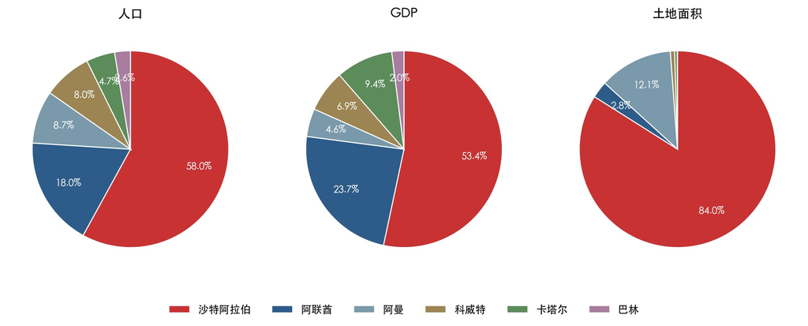

### 1.2.2 围绕波斯湾的海岸经济体

GCC 六国在地理上是一组环绕波斯湾的沿海经济体。除沙特和阿曼有较大内陆腹地，其余四国的人口、首都和核心经济活动高度集中在沿海带。这条狭窄的沿海带留下三处共同印记。

**城市集中在沿岸狭窄地带**。沙特国土辽阔，人口却聚集于三条走廊：内陆的利雅得（行政中心）、东海岸的达曼-赫巴尔（石油产业带）、西海岸的吉达-麦加-麦地那（港口与宗教中心）。其余五国的首都全部位于海岸：阿布扎比、多哈、科威特城、麦纳麦、马斯喀特。GCC 整体城市化率超过 85%，其中卡塔尔与科威特接近 100%，巴林约 90%，位列全球城市化程度最高的区域之一。

**波斯湾承担 GCC 的经济命脉**。GCC 约八成石油出口途经霍尔木兹海峡，使这条狭窄水道成为全球能源安全的关键节点。阿曼控制海峡南岸的穆桑达姆半岛（Musandam），由此长期在沙特与伊朗之间扮演调停角色。海峡上任何地缘紧张都会迅速传导至 GCC 的财政与外汇储备。

**气候极度严苛**。GCC 国土绝大部分属热带沙漠或半沙漠气候，夏季气温常年超过 45°C，年降水量不足 100 毫米；阿拉伯半岛南部的鲁卜哈利沙漠（Empty Quarter）面积约 65 万平方公里，几无人居。本就有限的「宜居带」还需靠海水淡化与进口食品维持运转。

图 2: 围绕波斯湾的 GCC 六国与海岸地理

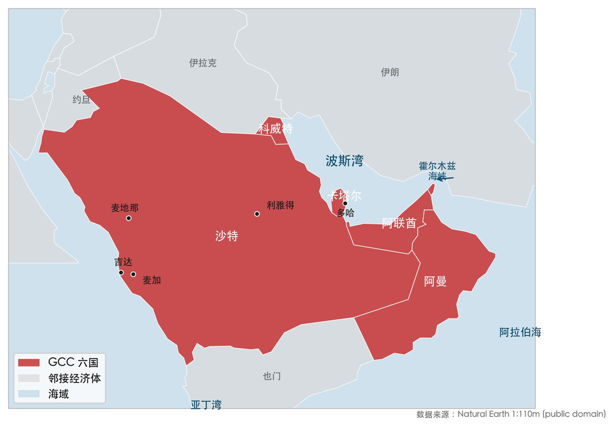

注：地图按 Natural Earth 1:110m 公开数据集绘制，底图数据 (Natural Earth 2026)。

### 1.2.3 高度同质的政治制度

六国均为世袭君主制（王国、苏丹国或酋长国），国家资产通常由国家或国有机构持有与管理，但关键任命、战略决策和财政分配权高度集中在统治家族主导的国家体系中 (Central Intelligence Agency 2023)。

- **单一君主制，行政权高度集中**：沙特（国王 Salman bin Abdulaziz Al Saud，2015 年即位；王储 Mohammed bin Salman 自 2022 年起任首相，通常简称 MBS）、阿曼（苏丹兼首相 Haitham bin Tariq，2020 年即位）、卡塔尔（埃米尔 Tamim bin Hamad Al Thani，2013 年即位）。三国均存在基本法、成文宪法或咨询机构，但内阁任命、国家战略和财政能源政策的最终权力仍集中于君主及其任命体系。
- **有议会制度设计、但王室仍主导行政与立法进程**：巴林（Hamad bin Isa Al Khalifa，1999 年起为国家元首，2002 年起称国王）、科威特（埃米尔 Mishal Al-Ahmad Al-Jaber Al-Sabah，2023 年 12 月即位）。
- **联邦君主制**：阿联酋。七个酋长国的世袭统治者组成联邦最高委员会；宪法上总统和副总统由最高委员会选出，总理由总统任命并经最高委员会批准。政治惯例上，总统由阿布扎比统治者担任（现任 Mohamed bin Zayed Al Nahyan，简称 MBZ），现任总理兼副总统为迪拜统治者 Mohammed bin Rashid Al Maktoum (UAE Cabinet 2026; The Official Portal of the UAE Government 2026)。

### 1.2.4 公民与外籍居民的二元结构

GCC 人口结构的另一特征是四个国家外籍居民多于本国公民；沙特和阿曼虽本国公民占多数，但外籍劳工比例也很高。GCC-Stat 2024 年末数据显示六国合计男性约 3,850 万、女性约 2,270 万，男性占比高达 62.8%，这并非自然人口结构，而是大规模男性劳工移民（建筑、能源、物流、家政）的结果。

表 3: GCC 六国公民与外籍居民比例（2024 年估算）

| 国家 | 公民比例 | 外籍比例 |
| --- | --- | --- |
| 阿联酋 | 12% | 88% |
| 卡塔尔 | 15% | 85% |
| 科威特 | 30% | 70% |
| 巴林 | 47% | 53% |
| 阿曼 | 60% | 40% |
| 沙特 | 58% | 42% |

注：公民比例综合各国统计局公开数据与第三方估算 (Gulf Labour Markets and Migration Programme 2024)；沙特、科威特、阿曼三国官方口径与本表略有差异（约 2-3 个百分点），阿联酋与卡塔尔无官方公民人口拆分。

这种二元结构会令所有「人均」类指标失真。媒体引用的「卡塔尔人均 GDP 7.7 万美元」分母是约 286 万常住人口，但仅约一成多的卡塔尔公民才有资格享受免税、住房补贴与免费医疗等公民福利；若以公民为分母，「公民人均」陡升至接近 50 万美元的量级。

这一「统计幻象」将是我们后续衡量 GCC「到底有多富」的核心议题。

# 2 衡量「到底有多富」

前文我们梳理了「中东」的多重概念，并将「中东土豪」的讨论范围限定在 GCC 六国。下一步是回答「到底有多土豪」这个问题。虽然「中东很有钱」是一个普遍的印象，但它仍然是一个模糊的概念，缺乏具体的衡量标准和数据支持。本节将从三个维度来审视 GCC 的财富：**流量**、**存量**和**结构**。从 GCC 整体到具体国家，再到具体阶层，逐步揭示 GCC 财富的全貌。

## 2.1 流量指标：GCC 总体是全球第 9 大经济体

### 2.1.1 总量：GDP 和 GNI（名义/PPP）

从 GDP / GNI 总量视角看，无论按名义还是 PPP 衡量，**GCC 整体都稳定居全球第 9**，规模介于意大利（名义）、印尼（PPP）相当。GCC 合计 GDP 名义 2.33 万亿美元、PPP 4.33 万亿国际美元；GNI 名义 2.36 万亿、PPP 4.39 万亿。PPP 校正主要让全球榜单本身重排（印度、俄罗斯、印尼大幅前移），但 GCC 的相对位置近乎不变。GCC 内部则高度集中：沙特一国 GDP 占 GCC 合计的 53%（名义）/ 58%（PPP）(World Bank 2026b, 2024)。

图 3: GCC 总量在全球的位置

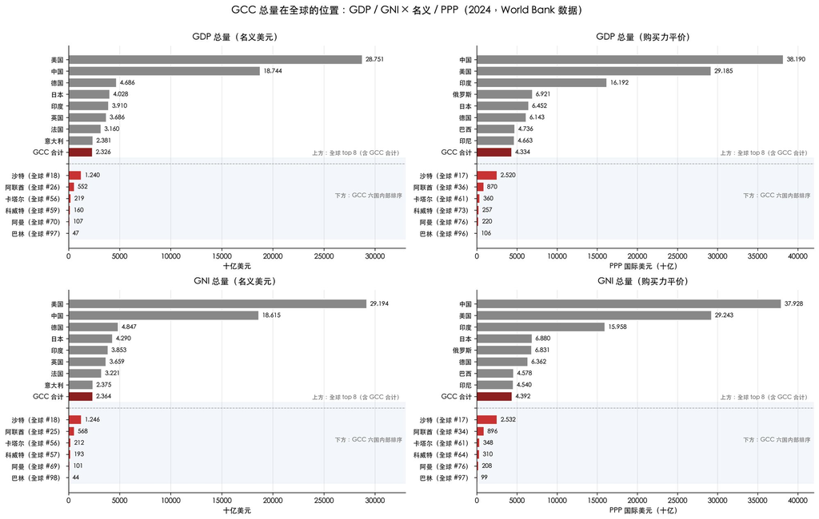

### 2.1.2 人均：GCC 内部呈梯度分化

PPP 校正后所有 GCC 国家排名都明显上移（GDP 口径下沙特上移 15 位、巴林 21 位最为显著，唯独科威特仅 +1 位、几乎持平），背后机制是本地物价被两层因素压低：**能源补贴**（沙特汽油约为美国的一半、德国的三分之一）；**廉价外籍劳工**（建筑、家政、零售工资普遍为发达国家的五分之一到十分之一）。两者叠加使 GCC 实际购买力显著高于名义美元收入。

此外，人均视角下，GCC 内部立刻呈现梯度分化。**卡塔尔**在全部四种人均口径下都进入全球 top 10，GNI PPP 口径下甚至升至全球第 3；**阿联酋**稳定在第二档（全球 #16~#25）；**沙特、巴林、科威特**位列第三档；**阿曼**最低（始终 #57~#65 区间）。

需要注意的是，**标准口径的「人均」分母都是常住人口（含外籍居民），不是公民数**。GCC 外籍人口占常住的 50%~90%，所以 GNI 和 GDP 人均都被显著稀释，这一点我们将在后续章节中进行调整和校正。

图 4: GCC 人均在全球的位置：GDP / GNI × 名义 / PPP 四宫格（2024，World Bank 数据）

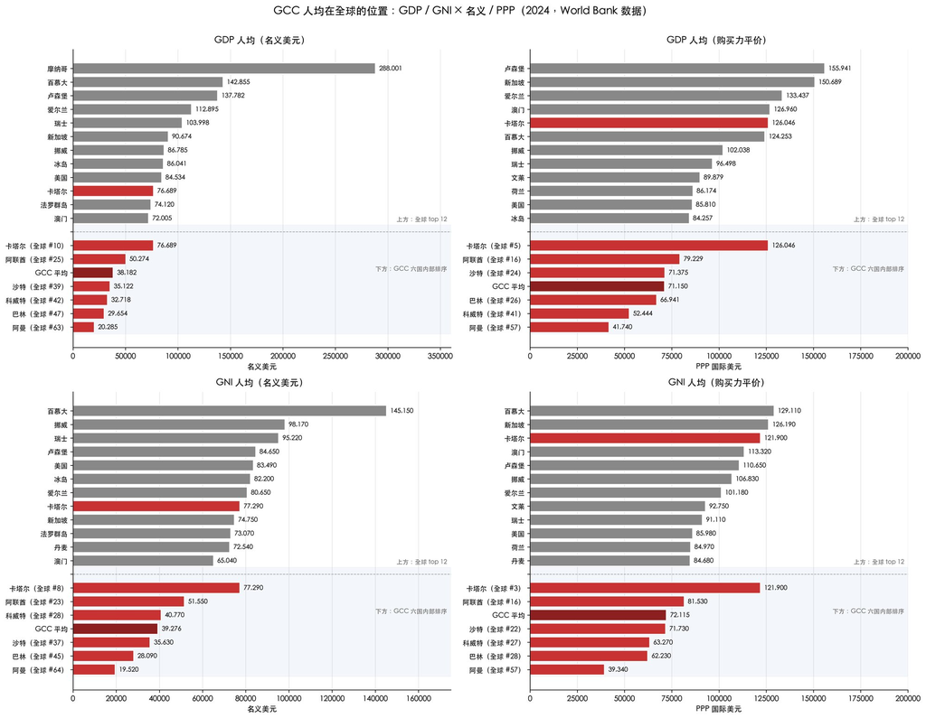

### 2.1.3 本节小结

表 4: GCC 六国与 GCC 整体在 8 个流量指标下的全球排名（2024，World Bank 数据）

| 指标 | 沙特 | 阿联酋 | 卡塔尔 | 科威特 | 巴林 | 阿曼 | GCC 整体 |
| --- | --- | --- | --- | --- | --- | --- | --- |
| **总量·GDP 名义** | 19 | 27 | 57 | 60 | 98 | 71 | **9** |
| **总量·GDP PPP** | 18 | 37 | 62 | 74 | 97 | 77 | **9** |
| **总量·GNI 名义** | 19 | 26 | 57 | 58 | 99 | 70 | **9** |
| **总量·GNI PPP** | 18 | 35 | 62 | 65 | 98 | 77 | **9** |
| **人均·GDP 名义** | 40 | 25 | **10** | 43 | 48 | 64 | 36 |
| **人均·GDP PPP** | 24 | 16 | **5** | 42 | 27 | 58 | 25 |
| **人均·GNI 名义** | 38 | 23 | **8** | 28 | 46 | 65 | 29 |
| **人均·GNI PPP** | 23 | 16 | **3** | 28 | 29 | 58 | 22 |

注：单元格为该国 / 该口径下的全球排名（数字越小越靠前）；**GCC 整体**列在总量口径下取六国之和、视为单一经济体重新排进 217 国列表，人均口径下取「GCC 总量 ÷ GCC 总人口」加权值后插入全球榜。**国别列的排名为「插入 GCC 整体后」的位置**（如卡塔尔 GDP 名义 #57 = GCC 整体插入第 9 位后所有原本第 10 位以下的国家排名各 +1 的结果）；图 图 3 / 图 4 显示的「全球 #N」是不含 GCC 整体的原始国别排名，与本表相差 1 位。卡塔尔人均行的粗体高亮其全球 top 10 位置。数据源：World Bank 2024（GDP / GNI 总量、人均 PPP 与人均名义）。

## 2.2 存量指标：GCC 整体是全球第一大主权投资者集合

本节按 SWF 与央行外储两类资产分别展开，探讨「GCC 半个世纪油气盈余累积成了多少财富」。理论上更全面的指标 NIIP（净对外资产）因 GCC 数据缺口（UAE / 卡塔尔无可靠官方序列）不进入主线分析，仅在 §2.2.2 末段简要说明。

### 2.2.1 主权财富基金：GCC 总量超6万亿美元

按 Caproasia 2026 年 1 月「Top 127 主权财富基金」宽口径名单（含纯主权基金、央行储备投资组合、公共养老金、州级基金、国家控股投资公司），**GCC 六国合计 SWF AUM 约 6.15 万亿美元**，规模超过任何其他单一国家集合（中国宽口径 3.76 万亿、挪威 GPFG 2.00 万亿）。**总量上**，阿联酋以 2.76 万亿位居单一国家第二；沙特 1.78 万亿（全球 #4）、科威特 KIA 1.00 万亿（#7）、卡塔尔 QIA 5,300 亿（#9）。

图 5: GCC 主权财富基金在全球的位置：总量 vs 人均（2026 年 1 月）

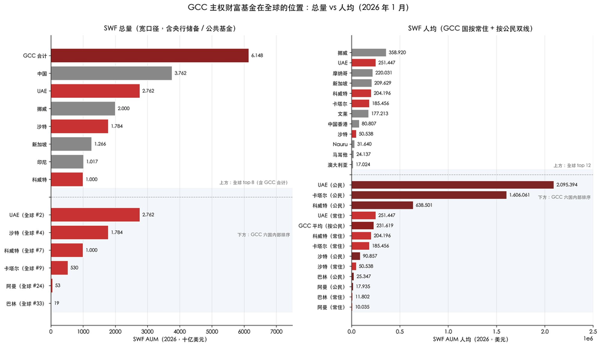

**人均上需要分两层口径看**。按常住人口口径，挪威 35.9 万美元全球第一，阿联酋 25.1 万 第二，科威特 20.4 万 第五，卡塔尔 18.5 万 第六，沙特 5.05 万 第九。但对国家资产，用**公民数**作分母更准确反映「人均拥有」（SWF 是国家代表公民管理的资产，归属于全体公民）。挪威由于外籍占常住比例小，两套口径数字基本一致；GCC 则差距悬殊。**GCC 平均（按公民）23.2 万美元，全球第三**，是常住口径（10.1 万）的 2.3 倍，相当于挪威的 65%。如果把每个 GCC 国家也按公民人口算（仅做分母替换），UAE 约 209 万 / 公民、卡塔尔约 161 万 / 公民、科威特约 64 万 / 公民，均远超挪威。

注：**Caproasia 宽口径**包含 ICD、Dubai World、Sharjah Asset Management 等更接近主权控股公司而非纯 SWF 的载体，与 Global SWF / SWFI 等狭口径相比规模偏大、可能含部分流动性储备和境内投资。**UAE 主权基金正在重组**：2026 年 1 月原 ADQ 资产并入新设的 L’imad Holding Abu Dhabi，部分另类资产管理转给独立的 Lunate（约 1,150 亿美元 AUM）；Mubadala 与 ADIA 也在调整对外投资平台 (Bloomberg 2026)。本文数据为 2026 年 1 月口径，未来 1-2 年法人结构与基金归属可能进一步变动。

需要注意的是，**SWF AUM 不等于「国家可支配的海外净财富」**。PIF 资产中估计约 60% 是境内（Aramco 股权、NEOM 等），真正能在海外灵活动用的部分远少于账面数字 (Global SWF 2026; International Monetary Fund 2025d)。这与主要海外配置的 ADIA、KIA、QIA 结构差异显著。

### 2.2.2 央行外汇储备：GCC 整体居全球第 5 位

按 World Bank 2024 年数据（含黄金）(World Bank 2026b)，**GCC 合计 8,298 亿美元，视为单一经济体全球第 5**：超过印度（6,433 亿）和俄罗斯（6,084 亿），仅次于中国 / 日本 / 美国 / 瑞士。

人均上同样分两层口径。按常住口径（全球榜单口径），瑞士 10.10 万居全球第一，阿联酋 2.17 万 / 人 全球第 6、卡塔尔 1.89 万 第 8、沙特 1.31 万 第 14、科威特 1.04 万 第 16。**按公民口径**，阿联酋 18.05 万 / 人，卡塔尔 16.36 万 / 人，均远超瑞士。外储是国家代表公民管理的流动性储备，公民分母更能反映人均防御能力。

图 6: GCC 央行外汇储备在全球的位置：总量 vs 人均（2024，World Bank WDI）

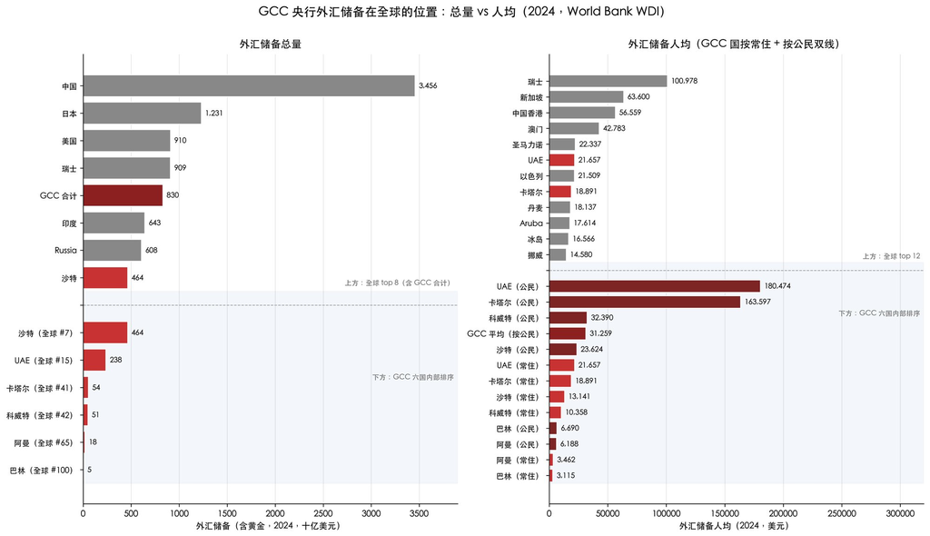

此外，国际比较层面，**NIIP（Net International Investment Position）**即居民对外资产减负债的净头寸，也是衡量国家对外金融存量的重要指标。但 GCC 在这一维度的数据缺口严重，因此本节**不对 NIIP 做单独全球排名分析**。可以记住的方向性事实：阿曼是 GCC 唯一公开为净对外负债的国家（对外债务超过 SWF + 外储合计），其余 GCC 国家普遍为大额净债权国。

### 2.2.3 本节小结

此外，将流量指标与存量指标并置，GCC 的**「存量重于流量」**特征非常突出。Caproasia 宽口径 SWF 已包含部分央行储备投资组合，与外储口径之间存在重叠，故不能简单做 SWF + 外储相加；但即便保守取 SWF 一项，GCC 整体 6.15 万亿美元就已相当于 GCC GDP 的 264%，是全球最高比例之一（远高于 G7 平均的 30–50%）。这意味着 GCC 财富很大部分已实现为存量。

表 5: GCC 六国与 GCC 整体在 4 项存量指标下的全球排名（2024-2026 年，人均按常住人口算）

| 指标 | 沙特 | 阿联酋 | 卡塔尔 | 科威特 | 巴林 | 阿曼 | GCC 整体 |
| --- | --- | --- | --- | --- | --- | --- | --- |
| **SWF·总量** | 4 | **2** | 9 | 7 | 33 | 24 | **1** |
| **SWF·人均** | 9 | **2** | **6** | **5** | 14 | 15 | 8 |
| **外储·总量** | **7** | 15 | 41 | 42 | 100 | 65 | **5** |
| **外储·人均** | 14 | **6** | **8** | 16 | 53 | 47 | 13 |

注：**人均口径**：国别人均与 GCC 整体人均均按常住人口（与全球榜单和图 图 5 / 图 6 一致）。**国别排名**为该国在不含 GCC 整体的全球榜上的位置；**GCC 整体**列把 GCC 视为单一经济体插入榜中后取得的位置（总量为六国之和、人均为常住口径加权）。SWF 用 Caproasia 2026 宽口径 Top 127；外储用 World Bank WDI 2024（含黄金）。

## 2.3 结构视角：清晰的社会财富阶层划分

### 2.3.1 方法

- `aptinc_pXXp100_992_j`：等分成年人税前国民收入平均值（含资本收益、SWF 隐含分配等 DINA 框架内的全部 NI 分配）
- `adiinc_pXXp100_992_j`：等分成年人税后可支配收入平均值（在 aptinc 基础上扣个税与社保、加现金转移；不含实物服务）

### 2.3.2 Top 1%/10%/20%收入对比

下表列出 16 国 Top 1% / Top 10% / Top 20% 平均成年人均收入，税前 + 税后两口径并列，单位美元 PPP，2022 校准。Top 1% 反映精英层、Top 10% 是常用的「上层」基准、Top 20% 含中产上层。

表 6: GCC 与 G7 / OECD 主要参照国 三分位数税前 + 税后对比（USD PPP，2022 校准）

| 国家 | Top 1% 税前 | Top 1% 税后 | Top 10% 税前 | Top 10% 税后 | Top 20% 税前 | Top 20% 税后 |
| --- | --- | --- | --- | --- | --- | --- |
| 卡塔尔 | 2,439,000 | 2,263,000 | 568,000 | 543,000 | 354,000 | 343,000 |
| 阿联酋 | 1,405,000 | 1,371,000 | 427,000 | 420,000 | 276,000 | 273,000 |
| 沙特 | 1,861,000 | 1,852,000 | 418,000 | 415,000 | 269,000 | 266,000 |
| 巴林 | 1,752,000 | 1,728,000 | 396,000 | 390,000 | 243,000 | 239,000 |
| 科威特 | 1,288,000 | 1,278,000 | 330,000 | 328,000 | 217,000 | 216,000 |
| 美国 | 1,840,000 | 1,273,000 | 416,000 | 326,000 | 274,000 | 226,000 |
| 挪威 | 997,000 | 808,000 | 321,000 | 275,000 | 240,000 | 210,000 |
| 阿曼 | 969,000 | 940,000 | 274,000 | 268,000 | 173,000 | 171,000 |
| 德国 | 998,000 | 770,000 | 283,000 | 230,000 | 197,000 | 165,000 |
| 加拿大 | 859,000 | 650,000 | 262,000 | 207,000 | 188,000 | 155,000 |
| 英国 | 965,000 | 683,000 | 262,000 | 204,000 | 184,000 | 150,000 |
| 瑞士 | 913,000 | 527,000 | 276,000 | 199,000 | 202,000 | 158,000 |
| 日本 | 634,000 | 504,000 | 218,000 | 183,000 | 136,000 | 119,000 |
| 韩国 | 764,000 | 644,000 | 205,000 | 182,000 | 145,000 | 132,000 |
| 法国 | 812,000 | 480,000 | 231,000 | 158,000 | 165,000 | 123,000 |
| 意大利 | 541,000 | 421,000 | 189,000 | 158,000 | 138,000 | 120,000 |

### 2.3.3 三个方向性发现

最直观的是税收差异制造的鸿沟。GCC 六国对就业收入均无个人所得税（阿曼 PIT 法已立法、2028 年起对超过 OMR 42,000 的高收入者征 5%），而 OECD 单身平均工资劳动者 2025 年「税楔」35.1%、顶层综合有效税率 22–38% (OECD 2026; PwC 2026)。Top 10% 从税前到税后：法国 $231K → $158K（−31%）、瑞士 $276K → $199K（−28%）、美国 / 英国 / 加拿大约 −22%、北欧 14–19%；GCC 一侧科威特 / 沙特 < 1%、巴林 / UAE / 阿曼 1–2%、卡塔尔 4%。这条单一机制就足以让 GCC 顶层在「实际拿到」的口径上跨出一档：美国 Top 10% 税后 $326K，与科威特 $328K 同档（差距仅 $2K），低于卡塔尔 $543K、UAE $420K、沙特 $415K、巴林 $390K 四国，介于挪威 $275K 与 GCC 中段之间。

Top 1% 视角下分化更清晰。卡塔尔精英层税后 $2.26M PPP，是美国 $1.27M 的 1.8 倍；沙特、巴林、UAE、科威特在 $1.28–1.85M 区间，全部高于美国。其他 G7 / OECD 集中在 $0.42–0.81M，GCC 精英顶层在「实际拿到」的口径上独占一档。

Top 20% 是另一幅画面。这一更宽分位数下，卡塔尔 $343K 仍然居首，但美国 $226K 介入到其余 GCC 中段（阿联酋 $273K、沙特 $266K、巴林 $239K、科威特 $216K、阿曼 $171K），与 OECD 高位国家（挪威 $210K）几乎重叠。Top 20% 区间已经混入相当数量的中级专业外籍（医生、工程师、教师），他们享受不到公民福利，拉低人均水平。

### 2.3.4 三层金字塔与分位数的映射

把上述分位数对比投射回 GCC 内部三层结构，可以看到分位数与人群层级之间存在自然映射。

图 7: GCC 财富金字塔示意：人数自上而下递增，单人财富自上而下递减

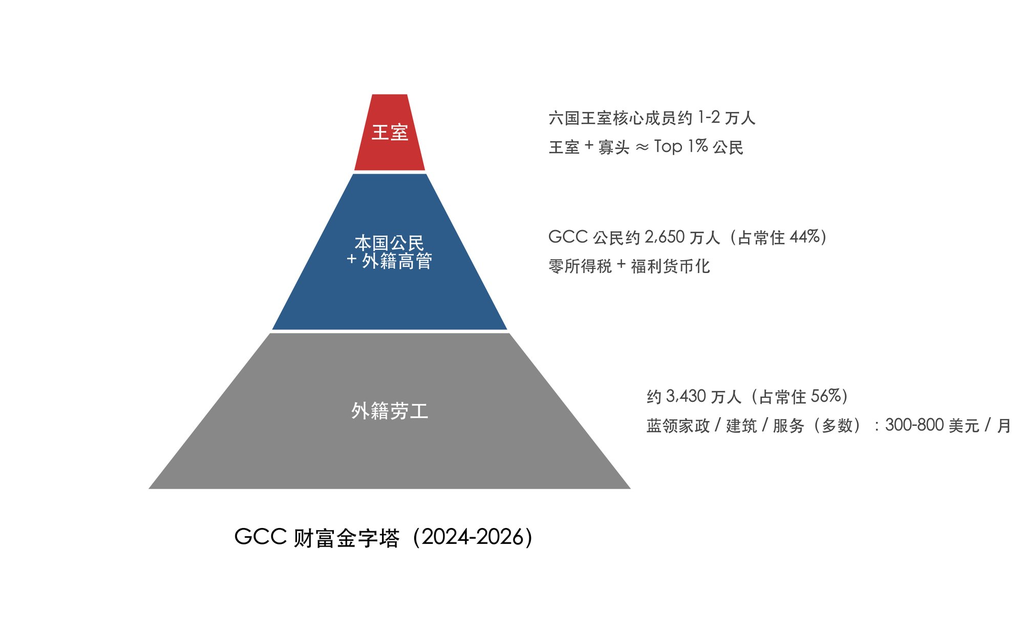

**顶层 ≈ Top 1%（王室扩展圈 + 顶级寡头）。** GCC 六国全是君主制，Top 1% 分位所反映的就是王室扩展圈 + 顶级商业寡头（卡塔尔 244 万、沙特 186 万、巴林 175 万、阿联酋 140 万、科威特 129 万、阿曼 97 万美元成年人均，PPP 税前）；王室核心成员的个人财富在公开统计中缺失，市场综合估算属「全球最富家族之列」的量级 (VnExpress 2024; Arab News 2025)。

**中层 ≈ Top 10%-50%（本国公民 + 外籍专业人士）。** 公民群体（约 2,650 万人）大致分布在 Top 10% 至 Top 50% 之间。其中政府高级雇员、王室关联企业管理层、高级专业人士构成 Top 10% 的主体；普通公民靠零所得税、住房地块、教育医疗补贴、公共部门优先就业、能源补贴整体处在 Top 20%-50%。

综合以上分析，**GCC 是一种独特的财富形态，不是 G7 的对照品，而是一个「已实现存量主导」的独立物种**。它在「已实现的财富」维度（流量、存量、公民可支配收入）上处于全球最前列，富裕GCC国家的本国公民的实际可支配更是全球最高一档。这也带来了新的研究问题，GCC的财富创造能力与石油的关联度如何，如果石油收入骤降，GCC的财富故事还能持续多久？这些我们将在后续章节继续讨论。

# 3 「为什么有钱」：从石油到财富的因果链

前文回顾了 GCC 财富的流量指标与存量指标，本节尝试回答GCC为什么这么有钱的问题。作为富裕的产油国，一切的出发点自然是石油。

## 3.1 一切从石油开始

**GCC 是全球最重要的油气资源集群之一**。按 Energy Institute Statistical Review of World Energy 2024，GCC 六国合计已探明石油储量约 510 十亿桶（即 5,100 亿桶），其中沙特一国占 267 十亿桶，居全球第二（仅次于委内瑞拉），阿联酋 111 十亿桶居全球第六，科威特 102 十亿桶居第七；天然气储量以卡塔尔的 24 万亿立方米为核心（全球第三，仅次于俄罗斯与伊朗），沙特 8.3 万亿立方米、阿联酋 5.9 万亿立方米、科威特 1.7、阿曼 0.6、巴林 0.1，GCC 合计占全球已探明天然气储量约 21%。把油与气按热值口径合并成「油当量」，**GCC 六国合计储量约 768 十亿桶油当量，占全球已探明油气储量的 27.5%**。产量方面，按 IMF 的产量口径，GCC 占全球油气产量约 1/5 (Mirzoev 等 2020)。

石油对 GCC 经济的影响力并不止于第一层的油井和炼厂。石油收入先以财政收入进入国家账户，再通过政府工资、价格补贴、公共项目、主权基金的国内投资，回流到所谓「非油」部门。下文从两个视角讨论石油对 GCC 经济的影响，一是**比例视角**（油气租金占 GDP 的比例、油气收入占政府财政收入的比例），二是**弹性视角**（油价变化 1% 引起 GDP 变化多少 %）。

图 8: 全球前 15 大油气资源国（2023 年末）

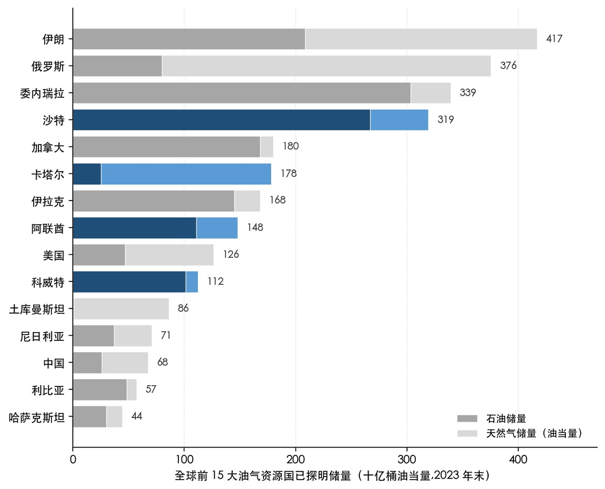

注：全球前 15 大油气资源国按 2023 年末已探明储量排序 (Energy Institute 2024)；油+气按 1 万亿立方米 ≈ 6.29 十亿桶油当量（boe）的标准热值口径合并；GCC 国家用蓝色高亮，其他国家用灰色。完整数据见 data/s3-1_global_hydrocarbon_reserves.csv。

### 3.1.1 比例视角：油气租金GDP占比大幅下降，但油气收入仍占财政收入 30%–90%

先看油气对整个国民经济的贡献。这里采用 World Bank 的**「油气租金占 GDP 比例」**（Oil and Gas Rents % of GDP）指标 (World Bank 2026c)。其口径定义是把油气产量按世界市场价计算出来的总价值，**减去全部生产成本**，得到的剩余即为该国油气资源在该年带给国民经济的「经济租金」（economic rent），再除以总名义 GDP 得到一个百分比。**百分比越高，表示该经济体对油气的依赖度越高**。

图 9: GCC 各国油气租金占 GDP 演变（2010–2021，World Bank）

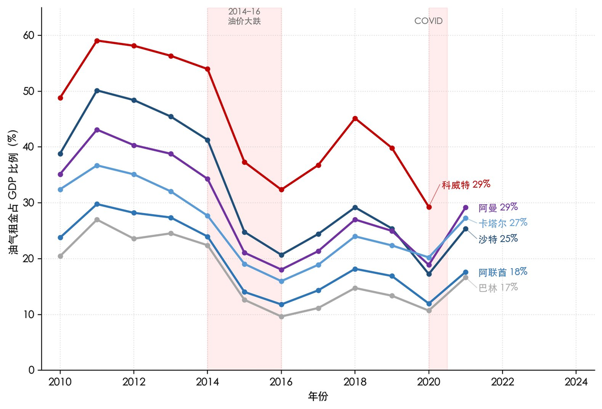

注：GCC 六国油气租金占 GDP 比例的时间序列，数据来自 World Bank Open Data 指标 NY.GDP.PETR.RT.ZS（油）+ NY.GDP.NGAS.RT.ZS（气）。粉色阴影标注 2014–16 油价大跌与 2020 年 COVID 两次外部冲击。科威特 2021 年数据缺失，最末点为 2020 年；其余五国到 2021 年。线末标签因部分数值接近做了垂直错位。完整数据见 data/s3-1_oil_gas_rents_pct_gdp.csv。

再看油气占政府财政收入的比例。这里政府的油气收入指的是政府从油气部门拿到的现金，包括特许权使用费（royalty）、公司所得税、国有油气公司分红（dividend）三项。按 IMF 的数据，GCC 六国财政对油气的依赖呈现明显的三梯度分化。**第一梯度**是科威特、卡塔尔、阿曼，油气占财政收入仍维持在 60% 以上，其中科威特最为极端，非油税收占 GDP 仅 5%，财政几乎完全靠油气支撑。**第二梯度**是沙特，油气依赖度从 2014 年的 85% 降至 2024 年的约 65%，主要由 Vision 2030 引入的 15% VAT、签证改革等扩大的非油收入推动。**第三梯度**只有阿联酋一国，联邦层面油气依赖度仅约 30–40%，但这主要是迪拜带动的结果，单看阿布扎比酋长国，油气仍占其财政收入约 70%。

表 7: GCC 六国对油气财政的依赖：三梯度分化

| 国家 | 2024-2025年油气占财政收入（%） | 油气占出口（%） |
| --- | --- | --- |
| 科威特 | 85–90 | 90+ |
| 卡塔尔 | 75–80 | 85+ |
| 沙特 | 60–70 | 70+ |
| 阿曼 | 60–70 | 65+ |
| 巴林 | 50–65 | 70 |
| 阿联酋 | 30–40 | 35 |

注：**数据来源** IMF GCC Policy Paper 2024 与各国最新 Article IV 报告整合 (International Monetary Fund 2024, 2025d, 2025e, 2026, 2025b, 2025a)，主要是 2024 年实际值或 2024–2025 staff projection；用区间表示是因为不同 IMF 报告对同一年份偶有微小修订，且部分国家联邦层面与酋长国层面的数字有差异。

上述两个指标综合来看，整个 GCC 经济确实在变得更多元，但政府收入的多元化进程慢得多，非油 GDP 的增长（旅游、地产、服务业）很多并没有变成政府的稳定税收。要量化 GCC 对油气收入的依赖程度，还可以看**财政平衡油价**（BEOP）和**非油初级余额**（NOPB）这两个 IMF 常用的指标。

「**财政平衡油价**」（Fiscal Break-even Oil Price，BEOP）的定义是让该国当年整体财政余额恰好为零的 Brent 油价。根据 IMF 数据，**GCC 加权平均 BEOP 在 2024 年已升至 $83.2/桶**，比 2020 年高出约 $10，主要原因是各国 Vision 战略推高公共投资支出 (Alby 2025)。逐国差异极大，**卡塔尔（约 $45）、阿联酋（2024 年 $54）、阿曼（$55）最低**（来源参见 IMF Article IV (International Monetary Fund 2025e, 2025a)）；**沙特 2025 年约 $94**，因 Vision 2030 投资强度大反成倒数第二；**科威特约 $80**（按预算口径，未计其主权基金投资收益）；**巴林约 $130 最高**（结构性贸易赤字加公共债务负担）。

「**非油初级余额**」（Non-Oil Primary Balance，简称 NOPB）的定义是非油收入扣除利息支出后占非油 GDP 的比例。按 IMF 数据，GCC 各国 NOPB 当前全部为负值，2024 年的赤字水平为：**科威特 −64%、卡塔尔 −33%、沙特 −32%、阿曼 −28%、阿联酋 −18%、巴林 −16%**。这说明 GCC 的财政收入结构仍然高度依赖油气，非油部门的增长并没有转化为政府的稳定税收来源。GCC 的财政可持续性在很大程度上仍然取决于油气收入的稳定性和持续性。

### 3.1.2 GDP 弹性视角：油价变 1%，GCC 名义 GDP 跟着变 0.4%–0.6%

关于 GCC 国家 GDP 对油价的敏感度，已有大量实证研究，计算的油价-GDP 弹性值大多在 0.4–0.6 区间 (Mohaddes 和 Pesaran 2016; Berument 等 2010; Cherif 等 2014)。这意味着油价变化 1%，GCC 名义 GDP 就会跟着变化 0.4%–0.6%。以沙特为例，如果油价下降 50%，按照 0.4–0.6 的弹性，沙特的名义 GDP 可能会下降 20%–30%。但前面的指标表明石油部门约占 GDP 25%，也就是说 12.5% 的 GDP 蒸发可由直接油气部门解释，剩余 7.5–17.5 个百分点则来自「非油」部门，说明这部分名义非油 GDP 实际是石油的「二次循环」（政府工资、补贴、公共采购的下游派生）。

把这一推断展开，GCC 的 GDP 可以分成三层。最底层是**直接油气层**，包括原油、天然气、石化、炼化业务，对油价直接敏感。中间一层是**二次循环层**，由油气财政支出驱动的非油部门构成（政府工资、基础设施建设、地产、国内零售），这一部分中的很多支出离开油价就难以维持。Citi 2026 年 3 月对 GCC 非油经济的拆分研究证实了这一层的实质，沙特的批发零售、餐饮、酒店部门占核心非油价值增加值的 17%，但其中「主要是国内零售而非旅游」，国内零售的需求来源正是政府工资和能源补贴 (Domac 和 Isiklar 2026a)。最上一层是**原生非油层**，面向全球市场或本地真实私人需求，比如迪拜的转口贸易、金融服务、高端旅游、物流枢纽。

目前，GCC 内部只有阿联酋通过迪拜模式形成了规模化的原生非油层，但 **多元化的方向并不一定降低风险**。Citi 2026 年的两份 GCC 研报指出，GCC 过去二十年的多元化方向集中在航空、旅游、物流、会展、地产。这些部门确实降低了直接油气依赖，但同时增加了对地缘冲突、空域关闭、外籍人口流动的暴露 (Domac 和 Isiklar 2026b)，面临新的多元化困境。

## 3.2 不止是石油

石油创造了 GCC 国家的巨额财富，但同样产油的国家不止 GCC。2024 年油气出口占 GDP 50% 以上的国家还包括伊朗、伊拉克、委内瑞拉、尼日利亚、安哥拉、阿尔及利亚，它们坐在同等乃至更大的油田之上，却没有一个像 GCC 那样把石油转化为长期累积的国家财富。那么是什么让 GCC 能把石油变成可持续财富？

回答这一问题需要从两个层次切入。第一个层次是**国家层面的成功条件**，即哪些条件让 GCC 区别于其他产油国，使石油美元能稳定累积成 SWF 与外汇储备。第二个层次是**国内层面的分配机制**，即王室、公民、外籍劳工三层财富画像（§2.3 已描绘）背后是什么制度安排使其稳定运行。这两个层次共同构成 GCC「rentier state」（租金国家）的完整运作逻辑，本节的最后一段会回到学理框架做总结，并接到 §4 关于「这套机制还能维持多久」的前瞻分析。

### 3.2.1 国家层面：政治稳定、美元同盟、早期 SWF、人口资源比

**第一是半个世纪的政治连续性。** 沙特 Al Saud 王朝从 1932 年延续至今，阿联酋的酋长家族（Al Nahyan、Al Maktoum 等）从 1971 年联邦成立至今，科威特 Al Sabah 家族从 1752 年延续至今、卡塔尔 Al Thani 家族从 1825 年延续至今、巴林 Al Khalifa 家族从 1783 年延续至今、阿曼 Al Said 家族从 1744 年延续至今，所有六国王室在过去 50 年都没有经历过实质性的政权更迭。这种连续性是其他产油国的失败案例普遍缺失的，伊朗 1979 年伊斯兰革命、利比亚 1969 年政变、伊拉克 1958 年与 2003 年两次政权更迭都伴随着财富累积的归零或重置。委内瑞拉 1999 年起的查韦斯政治改革则把油价高峰期的财政盈余全部用于补贴消费品价格而非储蓄，1998–2018 年货币贬值 99.999997%，2014–2021 年累计 GDP 下降 75–88%，被国际金融协会称为「45 年来非战争场景下规模最大的经济崩溃」(Council on Foreign Relations 2026a)。

**第二是与美国安全体系的深度绑定。** 1991 年沙特允许美军驻扎，阿联酋拥有 Al Dhafra 空军基地，卡塔尔的 Al Udeid 是美国中央司令部最重要的海外前进基地，巴林是美国第五舰队司令部所在地。这种安全同盟有具体的经济意义，它使 GCC 石油美元能稳定流入美元结算体系，SWF 资产能持续以美元计价的方式在全球资本市场配置。反观伊朗、委内瑞拉与俄罗斯，即便有油气收入也无法稳定转化为可在发达市场运作的全球资产组合。

### 3.2.2 分配机制：财富在三个阶层之间的稳定传递

§2.3 已描绘 GCC 的「三层金字塔」画像（参见 图 7），王室处于顶层、公民处于中层、外籍劳工处于底层。三层之间的稳定分配并非偶然形成的社会结构，而是三个相互嵌合的法律与政治机制叠加的产物。

**顶层是「国家即家族」的宪政事实**。GCC 六国的君主制不是隐喻而是法律安排。例如沙特国王同时是国家元首、政府首脑与武装力量统帅，PIF 的最终决策者直接是王储。这意味着讨论 GCC 6.15 万亿美元的 SWF 与 8,298 亿美元的外汇储备时，本质上是在讨论六个王室通过国家机制管理的财富。沙特 2017 年的「反腐」行动是这一逻辑的最直接体现：王储 Mohammed bin Salman 借此将分散于王室不同成员的财富重新集中到 PIF 之下，完成了「权力、财富、主权基金」的重新整合。

**中层是租金国家（rentier state）的「非政治化交换」**。Mahdavy (1970) 与 Beblawi (1987) 指出，当一个国家的财政收入主要来自外部资源租金而非国内税收时，国家与公民的关系会形成单向（国家发福利，公民不纳税）而非双向（公民交税换服务）的契约，公民也因此放弃了「无代议权不纳税」这一现代财政国家的核心政治诉求。GCC 把这一逻辑落到了四个具体制度上，**零所得税**（例外是阿曼 2025 年颁布将于 2028 年起对超过 OMR 42,000 收入征收 5% 的个税法）、**公共部门优先就业**（Hertog 2019 实证显示 GCC 公民在公共部门工资比私营部门外籍劳工高 1.5–4 倍 (Hertog 2019)）、**住房、燃料、教育、医疗的全面补贴**（继承自公民身份所对应的资源所有权，而非通过纳税换取的公共服务），以及**福利覆盖紧绑公民身份的排他性**。

对于 rentier state 模式的评价，学术界存在较大分歧。**悲观派**把 rentier state 视为长期发展的负面因素，即便短期富裕，长期也会因创新不足、女性劳动参与低、制度脆弱等结构性问题而失败。Karl (1997) 在《丰饶悖论》（The Paradox of Plenty）中论证，油气资源越丰富的国家长期增长率反而越低，因为「荷兰病」压垮制造业、财政依赖租金导致政府无需对纳税人负责、易得财富激发寻租与腐败 (Karl 1997)。Ross (2012) 在《石油诅咒》中用大样本回归证明，石油收入提高了威权制度的稳定性、降低了女性劳动参与、降低了民主转型概率 (Ross 2012)。Sachs 与 Warner (1995) 的早期跨国回归同样发现资源富裕度与增长率负相关 (Sachs 和 Warner 1995)。

**乐观派**则把 rentier state 视为一种特殊但稳定的政治-经济均衡。Hertog 等 (2019) 在 LSE 主导的 POMEPS Studies 33 中集中讨论了 GCC 的 rentier state 演变 (Hertog 2019)，核心论点是 GCC 的成功并非因为避开了「资源诅咒」，而是通过 SWF + 公民福利 + 君主制连续性把「资源诅咒」转化为「资源稳定器」，油气盈余在 SWF 中累积、公民通过福利包获得「分红」、王室通过这一交换换取政治稳定。Cherif、Hasanov 与 Zhu (2014) 则提示这一稳定性高度依赖油气收入持续，GCC 过去几十年的多元化主要发生在非贸易部门（服务、建筑），未能创造出真正独立于油气的高生产率出口部门 (Cherif 等 2014)。

这一分歧无法用现有数据完全裁决，需要等「后石油时代」（如果到来）的实证检验。但分歧本身也指出 rentier state 模式的核心脆弱性，即它假设国家能持续从外部获取足够规模的租金。如果石油收入显著下降，国家将被迫在三个选项中作出选择，一是削减福利（违背「分红」的隐性承诺，动摇公民对君主制的政治支持），二是扩大税收（引入「无代议权不纳税」的政治诉求空间，挑战君主制的根本政治架构），三是提高对外籍居民与企业的征收负担（短期可行，但损害 GCC 作为国际人才与资本枢纽的吸引力）。阿曼 2025 年的 5% 个税法是这一脆弱性的早期实证，尽管税率低、覆盖窄，它已经从制度上引入了一个长期可能导致政治结构变化的支点。这一变化是否会扩散，将取决于未来油气收入的轨迹与地缘冲击的演化。

## 3.3 前瞻：地缘冲突和能源转型的影响

### 3.3.1 近期地缘冲突：阿联酋最脆弱、阿曼相对受益

本节聚焦于 2026 年 2 月 28 日爆发的美伊冲突及其对 GCC 经济的传导，直接综述 IMF、Citi Research、AGSI 等机构在 2026 年 3–4 月发布的近期报告。这些分析指出，GCC 多元化最深的国家在地缘冲击下反而最脆弱，阿联酋而非卡塔尔是 GCC 中受冲击最严重的国家，因为开放服务业（航空、旅游、物流、零售）对地缘风险的暴露远高于纯石油经济。

IMF 2026 年 4 月 Middle East and Central Asia REO 把这场冲突的影响定义为**三重 disruption**，分别作用于能源市场、贸易路线与商业信心。在其参考情景下（假设贸易和能源生产到 2026 年中恢复正常），IMF 把 MENAP 2026 年 GDP 增长率下调至 1.4%，较 2025 年 10 月预测下调 **2.3 个百分点** (International Monetary Fund 2025c)。冲突具体的传导分四个层次。第一是能源渠道，霍尔木兹海峡通行接近停滞，约 20% 的全球油气贸易经此通过 (Schneider 2026)，IMF 称 GCC 油气产出大幅受扰；值得注意的是，油价上升不等于 GCC 整体受益，因为产量、运输与设施损伤可能同时下降，使理论上的油价红利无法落地。第二是 LNG 渠道，2024 年全球约 20% 的 LNG 贸易经过霍尔木兹，主要来自卡塔尔（9.3 Bcf/d）；冲突初期，卡塔尔能源（Qatar Energy）的 Ras Laffan 与 Mesaieed 工业城设施遭袭，LNG 生产一度全部中断 (Schneider 2026)，这使得卡塔尔在油气路径维度上是 GCC 中最脆弱的国家。第三是服务业渠道，海湾枢纽的空运、保险、航运、物流活动同步受冲击；AGSI 2026 年 3 月报告披露，迪拜、阿布扎比、科威特、卡塔尔的航空业一度全面瘫痪，仅斋月期间预期旅游损失就达 400 亿美元 (Smith Diwan 等 2026)。第四是金融渠道，主权信用利差扩大，资本流动波动加剧，UAE 交易所一度停市两天，海湾银行与房地产板块大幅下跌 (Schneider 2026)。

Citi Research 2026 年 3 月的两份研报提出了「**冲突敏感部门**」（Conflict-Sensitive Sectors，CSS）指数，把易受冲突影响的非油部门归为三类，分别是批发零售 / 餐饮 / 酒店（WRTRH，捕捉零售、住宿、旅游）、交通 / 仓储 / 通信（TSC，捕捉航空、海运、物流）、建筑业（CON，捕捉投资、外资、项目管线）(Domac 和 Isiklar 2026a)。这三类部门的共同特征是其需求或供应链直接暴露于安全冲击，比如空域关闭、海运延误、旅游停滞、外资项目暂停都会立即打击其产出。按总价值增加值（TVA）口径，2024 年 GCC 各国 CSS 占比从**科威特 15.5%、巴林与阿曼约 24%、卡塔尔 29.5%、沙特 31%、到阿联酋 36%（核心非油 VA 口径下升至 44%）**不等。这一分布揭示了**「多元化悖论」**，即 GCC 越成功地把经济多元化到航空、旅游、物流、会展、地产等服务业，在地缘冲击下反而越脆弱。

把 CSS 供给端指标与需求端指标（私人消费占 GDP、政府消费占 GDP、旅游业直接 GDP 贡献）综合后，Citi 给出的国家脆弱性排序对直觉做了重要修正。**阿联酋受冲击最严重**，CSS 36%、私人消费占 GDP 64%、旅游与商务对 GDP 贡献达 13%，开放服务业暴露最高，国内市场难以吸收。**卡塔尔**油气路径暴露最高，LNG 与 Ras Laffan 集中度极高，但私人消费仅占 GDP 25%，需求端缓冲明显，总冲击主要落在油气供给侧。**沙特**居中，CSS 31%，国内市场和政府消费提供部分缓冲，且部分通道可绕开霍尔木兹。**科威特**非油经济规模小反而降低了服务业暴露，但油气出口路径过度集中是另一种脆弱性。**巴林** CSS 24%、债务超过 GDP 130%，旅游与金融敏感而财政空间最弱。**阿曼相对受益**，海岸线在霍尔木兹之外，Duqm 港作为印度洋出口枢纽在当前局势下成为相对安全的替代节点。

# 4 综合结论

GCC 六国是中东地区的「富人俱乐部」。按流量看，2024 年 GCC 六国合计名义 GDP 约 2.33 万亿美元、全球排名第九，PPP 人均 7.1 万美元；按存量看，GCC 六国合计 SWF AUM 约 6.15 万亿美元，规模超过任何其他单一国家集合。GCC 财富的形成是石油作为必要条件、加上四个充分条件同时具备的产物，包括六国君主制延续半个世纪以上的政治连续性、与美国安全体系深度绑定、早期主权财富基金机制、有利的人口与资源比例。国内通过「国家即家族」「零税换沉默」「Kafala 排他」等法律与制度机制实现稳定分配。整体看，GCC 财富是已实现的存量优势叠加仍在运行的油气流量，长期可持续性最终取决于油气需求下降速度、GCC 资产转型速度、地缘冲突等多重因素的影响。

## 参考文献

Adelson, Roger. 1995. *London and the Invention of the Middle East: Money, Power, and War, 1902–1922*. Yale University Press.

Alby, Stéphane. 2025. *Gulf States: Falling Oil Prices Should Not Pose a Threat to Economic Diversification*. BNP Paribas Economic Research. https://economic-research.bnpparibas.com/Views/DisplayPublication.aspx?type=document&IdPdf=51600.

Alvaredo, Facundo, Lydia Assouad, 和 Thomas Piketty. 2019. 《Measuring Inequality in the Middle East 1990–2016: The World’s Most Unequal Region?》 *Review of Income and Wealth* 65 (4): 685～711. https://doi.org/10.1111/roiw.12385.

Arab News. 2025. *Saudi Arabia has Highest Number of Arab Billionaires: Forbes*. https://www.arabnews.com/node/2595776/business-economy.

Berument, M. Hakan, Nildag Basak Ceylan, 和 Nukhet Dogan. 2010. 《The Impact of Oil Price Shocks on the Economic Growth of Selected MENA Countries》. *The Energy Journal* 31 (1): 149～76.

Bloomberg. 2026. *Abu Dhabi to Consolidate Wealth Fund ADQ, L’imad Assets*. https://www.bloomberg.com/news/articles/2026-01-30/abu-dhabi-to-consolidate-wealth-fund-adq-l-imad-assets.

Central Intelligence Agency. 2023. *The World Factbook (2023 Archive): Government Type*. https://www.cia.gov/the-world-factbook/about/archives/2023/field/government-type/.

Cherif, Reda, Fuad Hasanov, 和 Min Zhu. 2014. *Soaring of the Gulf Falcons: Diversification in the GCC Oil Exporters in Seven Charts*. International Monetary Fund.

Cooperation Council for the Arab States of the Gulf. 1981. *The Charter*. https://gcc-sg.org/en/MediaCenter/DigitalLibrary/Documents/1274260830.pdf.

Council on Foreign Relations. 2026a. *Venezuela: The Rise and Fall of a Petrostate*. https://www.cfr.org/backgrounders/venezuela-crisis.

Council on Foreign Relations. 2026b. *What Is the Kafala System?* https://www.cfr.org/backgrounders/what-kafala-system.

Davison, Roderic H. 1960. 《Where is the Middle East?》 *Foreign Affairs* 38 (4): 665～75.

Domac, Ilker, 和 Gultekin Isiklar. 2026a. *Middle East Economics: GCC — Disaggregating Non-Oil Exposure to the Conflict*. Citi Research.

Domac, Ilker, 和 Gultekin Isiklar. 2026b. *Middle East Economics: Non-Oil GDP in the GCC — Assessing the Impact of the Conflict*. Citi Research.

Energy Institute. 2024. *Statistical Review of World Energy 2024*. https://www.energyinst.org/statistical-review.

GCC-Stat. 2024. *GCC Population Statistics 2024 (年末口径 6120 万)*. https://www.gulf-times.com/article/707291/region/gcc-countries-population-hit-612m-in-2024.

Global SWF. 2026. *Global SWF Ranking — Sovereign Wealth Funds and Public Pension Funds*. https://globalswf.com/ranking.

Gulf Labour Markets and Migration Programme. 2024. *GCC: Total Population and Percentage of Nationals and Non-Nationals (mid-2024)*. https://gulfmigration.grc.net/gcc-total-population-and-percentage-of-nationals-and-non-nationals-in-gcc-countries-national-statistics-mid-2024/.

Hertog, Steffen. 2019. 《What Would the Saudi Economy Have to Look Like to be Post-Rentier?》 *POMEPS Studies 33: The Politics of Rentier States in the Gulf*. https://eprints.lse.ac.uk/101386/1/Hertog_what_would_the_saudi_economy_have_to_look_like_to_be_post_rentier_published.pdf.

ILO. 2020. *The Migrant Pay Gap: Understanding Wage Differences*. https://www.ilo.org/sites/default/files/wcmsp5/groups/public/@ed_protect/@protrav/@migrant/documents/publication/wcms_763803.pdf.

International Monetary Fund. 2024. *Gulf Cooperation Council: Pursuing Visions Amid Geopolitical Turbulence*. https://www.imf.org/en/-/media/files/publications/pp/2024/english/ppea2024066.pdf.

International Monetary Fund. 2025a. *Oman: 2024 Article IV Consultation*. IMF Country Report No. 25/13. https://www.imf.org/-/media/files/publications/cr/2025/english/1omnea2025001-print-pdf.pdf.

International Monetary Fund. 2025b. *Qatar: 2024 Article IV Consultation*. https://www.imf.org/en/publications/cr/issues/2025/02/24/qatar-2024-article-iv-consultation-press-release-staff-report-and-statement-by-the-562636.

International Monetary Fund. 2025c. *Regional Economic Outlook: Middle East and Central Asia, May 2025 (Statistical Appendix)*. https://www.imf.org/-/media/files/publications/reo/mcd-cca/2025/may/english/regional-economic-outlook-middle-east-central-asia-may-2025-statistical-appendix.pdf.

International Monetary Fund. 2025d. *Saudi Arabia: 2025 Article IV Consultation*. https://www.imf.org/-/media/files/publications/cr/2025/english/1sauea2025001-source-pdf.pdf.

International Monetary Fund. 2025e. *United Arab Emirates: 2025 Article IV Consultation*. IMF Country Report No. 25/327. https://www.imf.org/-/media/files/publications/cr/2025/english/1areea2025001-source-pdf.pdf.

International Monetary Fund. 2026. *Kuwait: 2025 Article IV Consultation*. IMF Country Report No. 26/047. https://www.imf.org/-/media/files/publications/cr/2026/english/1kwtea2026001-source-pdf.pdf.

Karl, Terry Lynn. 1997. *The Paradox of Plenty: Oil Booms and Petro-States*. University of California Press.

Mahan, Alfred Thayer. 1902. 《The Persian Gulf and International Relations》. *National Review*, 九月.

Migration Policy Institute. 2024. *As the Gulf Region Seeks a Pivot, Reforms to Its Oft-Criticized Immigration Policies Remain a Work in Progress*. https://www.migrationpolicy.org/article/gulf-region-gcc-migration-kafala-reforms.

Mirzoev, Tokhir, Ling Zhu, Yang Yang, Andrea Pescatori, 和 Akito Matsumoto. 2020. *The Future of Oil and Fiscal Sustainability in the GCC Region*. IMF Departmental Paper No. 20/01; International Monetary Fund. https://www.imf.org/en/publications/departmental-papers-policy-papers/issues/2020/01/31/the-future-of-oil-and-fiscal-sustainability-in-the-gcc-region-48934.

Mohaddes, Kamiar, 和 M. Hashem Pesaran. 2016. 《Country-Specific Oil Supply Shocks and the Global Economy: A Counterfactual Analysis》. *Energy Economics* 56: 18～30.

Natural Earth. 2026. *Natural Earth — 1:110m Cultural Vectors (Admin 0 Countries)*. https://github.com/nvkelso/natural-earth-vector/blob/master/geojson/ne_110m_admin_0_countries.geojson.

OECD. 2026. *Taxing Wages 2026*. https://www.oecd.org/tax/taxing-wages-19991029.htm.

PwC. 2026. *Worldwide Tax Summaries — Personal Income Tax Rates by Country (2026)*. https://taxsummaries.pwc.com/.

Ross, Michael L. 2012. *The Oil Curse: How Petroleum Wealth Shapes the Development of Nations*. Princeton University Press.

Sachs, Jeffrey D., 和 Andrew M. Warner. 1995. *Natural Resource Abundance and Economic Growth*. NBER Working Paper No. 5398. National Bureau of Economic Research.

Schneider, Frédéric. 2026. *The Costs of the Iran Conflict for the Gulf*. Middle East Council on Global Affairs Blog. https://mecouncil.org/blog_posts/the-costs-of-the-iran-conflict-for-the-gulf/.

Smith Diwan, Kristin, David B. Roberts, Robert Mogielnicki, Mohammed Baharoon, Sara Bazoobandi, 和 Aziz Alghashian. 2026. *Iran War: Gulf Unity, Economic Shocks, and Regime Scenarios*. Arab Gulf States Institute in Washington (AGSI) Analysis. https://agsi.org/analysis/iran-war-gulf-unity-economic-shocks-and-regime-scenarios/.

The Official Portal of the UAE Government. 2026. *The Federal Government*. https://u.ae/en/about-the-uae/the-uae-government/the-federal-government.

UAE Cabinet. 2026. *The Constitution of the United Arab Emirates*. https://uaecabinet.ae/en/the-constitution.

United Nations Statistics Division. 2026. *Standard country or area codes for statistical use (M49)*. https://unstats.un.org/unsd/methodology/m49/.

U.S. Department of State. 2026. *Bureau of Near Eastern Affairs*. https://www.state.gov/bureaus-offices/under-secretary-for-political-affairs/bureau-of-near-eastern-affairs.

VnExpress. 2024. *World’s 5 Richest Families Own $1.4T in Combined Wealth, Dominated by Arab Royals*. https://e.vnexpress.net/news/business/billionaires/world-s-5-richest-families-own-1-4t-in-combined-wealth-dominated-by-arab-royals-4994396.html.

World Bank. 2024. *GNI per capita, Atlas method (current US$) — Indicator NY.GNP.PCAP.CD*. https://data.worldbank.org/indicator/NY.GNP.PCAP.CD.

World Bank. 2025. *World Bank Country and Lending Groups (FY2026)*. https://datahelpdesk.worldbank.org/knowledgebase/articles/906519-world-bank-country-and-lending-groups.

World Bank. 2026a. *World Bank DataBank — Land Area (sq. km), Indicator AG.LND.TOTL.K2*. https://databank.worldbank.org/metadataglossary/world-development-indicators/series/AG.LND.TOTL.K2.

World Bank. 2026b. *World Bank Open Data — GCC Six Countries (Saudi Arabia, UAE, Qatar, Kuwait, Bahrain, Oman)*. https://data.worldbank.org/?locations=SA-AE-KW-BH-OM-QA.

World Bank. 2026c. *World Bank Open Data — Oil Rents (% of GDP) NY.GDP.PETR.RT.ZS + Natural Gas Rents (% of GDP) NY.GDP.NGAS.RT.ZS*. https://data.worldbank.org/indicator/NY.GDP.PETR.RT.ZS.